# **How Spending Impacts Performance in the Premier League**

[figure not shown]

How does spending impact the ranking of a team in the Premier League?

###### Valeria Arriola Pomasoncco & John Passalis

# Introduction

The soccer industry has been booming over the past couple of years. The sport’s current operating income is averaged out to be 84 million US Dollars, which is the highest it has ever been. With teams like Manchester United valued to be 4.12 billion US Dollars, it’s not hard to see how such teams have the potential to succeed. Teams get money from ticket sales, merchandise sales, sponsorships, ownership, television deals, and other forms of publicity. Teams with the biggest fanbase make the most income which they can spend on bringing in new and better players that help the team with the top of their league. Money is the biggest factor in creating some of the best soccer teams in the world. But one team defied the odds.

Using data from the transfer market relating to the Premier League, our group will collect, tidy, and examine this data to analyze the impact of money and spending has on a soccer team’s placement in the Premier League. We will then use this data to then predict how teams could rank in the league table based on their spendings. We hope that our readers, both unfamiliar and familiar to the sport, find this tutorial intriguing as we delve into another side of soccer not usually broadcasted, the side that now matters just as much as the game itself.

# Getting Started

## Required Libraries

We take advantage of Python’s shared libraries and import sqlite3, pandas, BeautifulSoup, regex, matplotlib, and SciKit - Learn

1. Pandas:https://pandas.pydata.org/pandas-docs/stable/
2. Sqlite3: https://docs.python.org/3/library/sqlite3.html
3. BeautifulSoup: https://www.crummy.com/software/BeautifulSoup/bs4/doc/
4. Regex: https://docs.python.org/3/library/re.html
5. Matplotlib: https://matplotlib.org/
6. SciKit-Learn: https://scikit-learn.org/stable/

```python
# Required libraries that we imported
import sqlite3
import pandas as pd
import requests
from bs4 import BeautifulSoup
import pandas as pd
import re
from matplotlib import pyplot as plt
from sklearn import datasets, linear_model, model_selection
```

# Data Sources

We use the data provided by Transfer Markt https://www.transfermarkt.us, a website that has the statistics of past and current soccer league transfers, goals, player positions, and other information relating to soccer. Specifically, we used the financial data they provided over the transfer values over the years.

## Preprocessing Data - Part 1

Before we could work with the data, we first had to retrieve it from the site. Upon trying to retrieve the data, we realized that the original data we are trying to work with was being pulled from multiple sites. We used GET requests to access the sites that have the data and then proceeded to grab the correct table from the specific website and parse it into a readable format using BeautifulSoup and .prettify().

To better display and analyze our data, we thought it would be best to split the data between two DataFrames, one for financial data and the other for team data.

Now having the correct financial data table and storing in it a DataFrame, we can tidy and modify the data to properly analyze it. After adding a column for the current season in every entry of financial data in the data table, we fix the columns to have correct labels. This is also a good moment to drop the columns we are not currently using. Properly labeled and organized, this table is added to a larger DataFrame that will hold both the financial and the team tables. We will call this big DataFrame the “grand table”.

```python
# Split link into 3 parts in order to change numbers in the GET requests later
linkPart1 = 'https://www.transfermarkt.us/premier-league/einnahmenausgaben/wettbewerb/GB1/plus/0?ids=a&sa=&saison_id='
linkPart2 = '&saison_id_bis='
linkPart3 = '&nat=&pos=&altersklasse=&w_s=&leihe=&intern=0'

# DataFrame where all of the data will be stored
df = pd.DataFrame([], columns = ["Spending_Rank", "Season", "Club", "Expenditure", "Arrivals", "Income", "Departures", "Balance"])

# For loop collecting the financial data
for i in range(1978, 2019):
    link = linkPart1 + str(i) + linkPart2 + str(i) + linkPart3

    # Get request accessing the sites which have the data
    headers = {'User-Agent': 'Mozilla/5.0 (Windows NT 6.1; WOW64) AppleWebKit/537.36 (KHTML, like Gecko) Chrome/56.0.2924.76 Safari/537.36', "Upgrade-Insecure-Requests": "1","DNT": "1","Accept": "text/html,application/xhtml+xml,application/xml;q=0.9,*/*;q=0.8","Accept-Language": "en-US,en;q=0.5","Accept-Encoding": "gzip, deflate"}
    r = requests.get(link, headers=headers)

    # Grabbing the correct table from the specific website and parsing it into a readable format / table
    root = BeautifulSoup(r.content)
    table = root.find_all("table")[3].prettify()
    data = (pd.read_html(table))[0]

    # Adding a column for the current season
    data["Season"] = i

    # Fixing the columns to all have the correct data
    data.columns = ["Spending_Rank", "drop", "Club", "Expenditure", "Arrivals", "Income", "Departures", "Balance", "drop2", "Season"]
    data = data.drop(columns=['drop', 'drop2'])
    data = data[["Spending_Rank", "Season", "Club", "Expenditure", "Arrivals", "Income", "Departures", "Balance"]]
    temp = pd.DataFrame(data)

    # Adding the new table for the specific season to the grand table
    df = pd.concat([df, temp])
```

Below is a sample of what the table looks like once all of the data is scraped from the various requests made to the site to get the financial information.

```python
df.head(3)
```

|  | Spending_Rank | Season | Club | Expenditure | Arrivals | Income | Departures | Balance |
| --- | --- | --- | --- | --- | --- | --- | --- | --- |
| 0 | 1 | 1978 | Manchester United | $1.12m | 8 | $428k | 4 | -608 K $ |
| 1 | 2 | 1978 | Chelsea FC | $776k | 9 | $352k | 7 | -372 K $ |
| 2 | 3 | 1978 | Arsenal FC | $684k | 6 | $114k | 3 | -500 K $ |

Fortunately, the data which is scrapped from the site fits well into the table and does not need much tidying.

## Preprocessing Data - Part 2

With the financial set of data cleaned up, we can now work on the team data. For the positioning of teams in the Premier League table, we used Wikipedia https://www.wikipedia.org/. They had general information on the league from year to year, as well as a table full of information on each season we were interested in.

We create empty columns for this second DataFrame and label them to fit the team data we will be collecting from our source. The columns are labeled to represent this information: season, team, position, games played, wins, draws, losses, goals for, goals against, goal difference, and points. A similar process to getting the financial information from Transfer Markt, we use GET requests to get the table information from the website. This gives us the league tables for each year which then gets parsed into a readable format using BeautifulSoup. It is important to note that in 1992, the league went through a restructure taking the top 20 teams from the Football League which went on to become the Premier League. This was taken into account when scraping the data from the site. We had to change the link of the website to say “_Premier_League” in order to access the sites with data.

```python
df2 = pd.DataFrame([], columns = ["Season", "Team", "Pos", "Pld", "W", "D", "L", "GF", "GA", "GD", "Pts"])

# The first part of the link where the league tables will be collected from
partLink = 'https://en.wikipedia.org/wiki/'

# Looping through all of the years to get each table
for i in range(1978, 2019):

    # Adding the year of the league table we are trying to get to the link
    link = partLink + str(i) + '-' + str(i + 1)[2:]

    # The league went through a name change / restructuring, hence the different link
    if (i < 1992):
        link = link + "_Football_League"
    else:
        link = link + "_Premier_League"

    # Get request accessing the sites which have the data
    headers = {'User-Agent': 'Mozilla/5.0 (Windows NT 6.1; WOW64) AppleWebKit/537.36 (KHTML, like Gecko) Chrome/56.0.2924.76 Safari/537.36', "Upgrade-Insecure-Requests": "1","DNT": "1","Accept": "text/html,application/xhtml+xml,application/xml;q=0.9,*/*;q=0.8","Accept-Language": "en-US,en;q=0.5","Accept-Encoding": "gzip, deflate"}
    r = requests.get(link, headers=headers)

    # Grabbing the correct table from the specific website and parsing it into a readable format / table
    root = BeautifulSoup(r.content)
```

When we collected this data, we realized that there would need to be a fair bit of tyding on this set of data, as the tables contain slightly different information which would not match when trying to combine it in one table.

## Tyding the Data

The team data collected from Wikipedia gives us the number of goals, losses, draws, goals for, and goals against for home games and away games. Since we are only worrying about total scores, we do some simple arithmetic to calculate the total wins, total draws, total losses, total goals for, and total goals against. Once calculated and simplified, we drop the columns that mark the “away” and “home” data and work with the totals we calculated.

While collecting data, we encountered some small issues such as tables having different column names in random spots or finding tables at different points on the page. This was accounted for when modifying the data tables so the collected data could be as cohesive as possible before being added to the grand table.

```python
# In 1992, the league went through a change, so the pages are formatted differently different
if (i < 1991):

    # Here, the tables are found at different points on the web page
    if i == 1987:
        table = root.find_all("table")[3].prettify()
    else:
        table = root.find_all("table")[2].prettify()

    data = (pd.read_html(table))[0]

    # Here, we are simplifying the different columns into win, loss, draw, goals for, goals against
    data['W'] = data['HW'] + data['AW']
    data['D'] = data['HD'] + data['AD']
    data['L'] = data['HL'] + data['AL']
    data['GF'] = data['HGF'] + data['AGF']
    data['GA'] = data['HGA'] + data['AGA']

    data = data.drop(columns=['HW', 'HD', 'HL', 'HGF', 'HGA', 'AW', 'AD', 'AL', 'AGF', 'AGA', data.columns[len(data.columns) - 6]])

    # Two of the years, the table had different columnn names in random spots
    if (i == 1989 or i == 1990):
        data.columns = ['Pos', 'Team', 'Pld', 'GD', 'Pts', 'W', 'D', 'L', 'GF',
   'GA']

else:
    # Here, the tables are found at different points on the page
    if (i == 2016 or i == 2012 or i == 2005 or (i > 1997 and i < 2002)):
        table = root.find_all("table")[5].prettify()
    elif (i == 2003):
        table = root.find_all("table")[7].prettify()
    else:
        table = root.find_all("table")[4].prettify()

    data = (pd.read_html(table))[0]

    # Again, simplying the table in to more useful columns
    if (i == 1991):
        data['W'] = data['HW'] + data['AW']
        data['D'] = data['HD'] + data['AD']
        data['L'] = data['HL'] + data['AL']
        data['GF'] = data['HGF'] + data['AGF']
        data['GA'] = data['HGA'] + data['AGA']

        data = data.drop(columns=['HW', 'HD', 'HL', 'HGF', 'HGA', 'AW', 'AD', 'AL', 'AGF', 'AGA', data.columns[len(data.columns) - 6]])

    else:
        data = data.drop(data.columns[len(data.columns) - 1], axis = 1)
```

Below is a sample of what the table looks like once all of the data is cleaned up from the various requests made to the site to get the standings information.

```python
df2.head(25)
```

|  | Season | Team | Pos | Pld | W | D | L | GF | GA | GD | Pts |
| --- | --- | --- | --- | --- | --- | --- | --- | --- | --- | --- | --- |
| 0 | 1978 | Liverpool | 1 | 42 | 30 | 8 | 4 | 85 | 16 | +69 | 68 |
| 1 | 1978 | Nottingham Forest | 2 | 42 | 21 | 18 | 3 | 61 | 26 | +35 | 60 |
| 2 | 1978 | West Bromwich Albion | 3 | 42 | 24 | 11 | 7 | 72 | 35 | +37 | 59 |
| 3 | 1978 | Everton | 4 | 42 | 17 | 17 | 8 | 52 | 40 | +12 | 51 |
| 4 | 1978 | Leeds United | 5 | 42 | 18 | 14 | 10 | 70 | 52 | +18 | 50 |
| 5 | 1978 | Ipswich Town | 6 | 42 | 20 | 9 | 13 | 63 | 49 | +14 | 49 |
| 6 | 1978 | Arsenal | 7 | 42 | 17 | 14 | 11 | 61 | 48 | +13 | 48 |
| 7 | 1978 | Aston Villa | 8 | 42 | 15 | 16 | 11 | 59 | 49 | +10 | 46 |
| 8 | 1978 | Manchester United | 9 | 42 | 15 | 15 | 12 | 60 | 63 | −3 | 45 |
| 9 | 1978 | Coventry City | 10 | 42 | 14 | 16 | 12 | 58 | 68 | −10 | 44 |
| 10 | 1978 | Tottenham Hotspur | 11 | 42 | 13 | 15 | 14 | 48 | 61 | −13 | 41 |
| 11 | 1978 | Middlesbrough | 12 | 42 | 15 | 10 | 17 | 57 | 50 | +7 | 40 |
| 12 | 1978 | Bristol City | 13 | 42 | 15 | 10 | 17 | 47 | 51 | −4 | 40 |
| 13 | 1978 | Southampton | 14 | 42 | 12 | 16 | 14 | 47 | 53 | −6 | 40 |
| 14 | 1978 | Manchester City | 15 | 42 | 13 | 13 | 16 | 58 | 56 | +2 | 39 |
| 15 | 1978 | Norwich City | 16 | 42 | 7 | 23 | 12 | 51 | 57 | −6 | 37 |
| 16 | 1978 | Bolton Wanderers | 17 | 42 | 12 | 11 | 19 | 54 | 75 | −21 | 35 |
| 17 | 1978 | Wolverhampton Wanderers | 18 | 42 | 13 | 8 | 21 | 44 | 68 | −24 | 34 |
| 18 | 1978 | Derby County | 19 | 42 | 10 | 11 | 21 | 44 | 71 | −27 | 31 |
| 19 | 1978 | Queens Park Rangers | 20 | 42 | 6 | 13 | 23 | 45 | 73 | −28 | 25 |
| 20 | 1978 | Birmingham City | 21 | 42 | 6 | 10 | 26 | 37 | 64 | −27 | 22 |
| 21 | 1978 | Chelsea | 22 | 42 | 5 | 10 | 27 | 44 | 92 | −48 | 20 |
| 0 | 1979 | Liverpool | 1 | 42 | 25 | 10 | 7 | 81 | 30 | +51 | 60 |
| 1 | 1979 | Manchester United | 2 | 42 | 24 | 10 | 8 | 65 | 35 | +30 | 58 |
| 2 | 1979 | Ipswich Town | 3 | 42 | 22 | 9 | 11 | 68 | 39 | +29 | 53 |

## More Modifying

Now that we have two tidy and modified data frames, we can complete our grand table combining the financial information DataFrame and the team information DataFrame into one. To do so, we have to do some final modifications to the individual DataFrames so they can be easily merged.

We set initial column values, update indices, and choose uniform characters that will be shared amongst both tables. In order to maintain the old information and make sure it does not change when we do opertations, we make a copy of the data creating a new DataFrame.

Now having our data safely stored, we begin to combine the columns of the two individual DataFrames to create our grand table with financial and league standing data from our two different sources.

```python
# Setting inital values to 0 (meaning no transfer fee was recorded for this team)
df2["Expenditure"] = "0"
df2["Arrivals"] = "0"
df2["Income"] = "0"
df2["Departures"] = "0"
df2["Balance"] = "0"

# The indices were wrong initiall, so we change them to go from 0 to 1
df2.index = range(len(df2))
df.index = range(len(df))

# Some of the names of the team had stray characters. We are removing those stray characters and spaces
for i, j in df2.iterrows():

    # R is relegated
    if (type(j.Team) != float and "(R)" in j.Team):
        df2.at[i, "Team"] = j.Team.replace("(R)", "").strip()

    # C is Champion
    if (type(j.Team) != float and "(C)" in j.Team):
        df2.at[i, "Team"] = j.Team.replace("(C)", "").strip()

# Here we copy this table in to a new DataFrame, so that we do not damage the old information with new operations
df3 = pd.DataFrame(df2)

# Here, We are now going ahead and finally combining the finance aspect of the data, with the league standing information
for i, j in df3.iterrows():
    # Copy down the current season
    currYear = df[df["Season"] == j.Season]

    # Going through each team for the given season
    for index, currTeam in currYear.iterrows():

        # Making sure the team is not a Nan and also matching the two different tables into one
        if (type(df3.iloc[i]["Team"]) != float and df3.iloc[i]["Team"] in currTeam["Club"]):
            df3.at[i, "Expenditure"] = currTeam["Expenditure"]
            df3.at[i, "Arrivals"] = currTeam["Arrivals"]
            df3.at[i, "Income"] = currTeam["Income"]
            df3.at[i, "Departures"] = currTeam["Departures"]
            df3.at[i, "Balance"] = currTeam["Balance"]
```

Below is a sample of what the table looks like once all of the data is combined and modified from the two table which contained the standings information and financial information.

```python
df3.head(9)
```

|  | Season | Team | Pos | Pld | W | D | L | GF | GA | GD | Pts | Expenditure | Arrivals | Income | Departures | Balance |
| --- | --- | --- | --- | --- | --- | --- | --- | --- | --- | --- | --- | --- | --- | --- | --- | --- |
| 0 | 1978 | Liverpool | 1 | 42 | 30 | 8 | 4 | 85 | 16 | +69 | 68 | $561k | 4 | $285k | 5 | -243 K $ |
| 1 | 1978 | Nottingham Forest | 2 | 42 | 21 | 18 | 3 | 61 | 26 | +35 | 60 | 0 | 0 | 0 | 0 | 0 |
| 2 | 1978 | West Bromwich Albion | 3 | 42 | 24 | 11 | 7 | 72 | 35 | +37 | 59 | 0 | 0 | 0 | 0 | 0 |
| 3 | 1978 | Everton | 4 | 42 | 17 | 17 | 8 | 52 | 40 | +12 | 51 | $114k | 6 | $336k | 8 | 195 K $ |
| 4 | 1978 | Leeds United | 5 | 42 | 18 | 14 | 10 | 70 | 52 | +18 | 50 | 0 | 0 | 0 | 0 | 0 |
| 5 | 1978 | Ipswich Town | 6 | 42 | 20 | 9 | 13 | 63 | 49 | +14 | 49 | 0 | 0 | 0 | 0 | 0 |
| 6 | 1978 | Arsenal | 7 | 42 | 17 | 14 | 11 | 61 | 48 | +13 | 48 | $684k | 6 | $114k | 3 | -500 K $ |
| 7 | 1978 | Aston Villa | 8 | 42 | 15 | 16 | 11 | 59 | 49 | +10 | 46 | $131k | 5 | $197k | 4 | 58 K $ |
| 8 | 1978 | Manchester United | 9 | 42 | 15 | 15 | 12 | 60 | 63 | −3 | 45 | $1.12m | 8 | $428k | 4 | -608 K $ |

# Analysis

## Graphing Data

Now that we have our data organized and set in one big table, we can do our analysis. Let's take the top 5 teams and bottom 5 teams in terms of spending and see their league placement in the table. This will give us a rough idea of how money influences the league.

### Helper Functions

We create some helper functions so that graphing the top and bottom 5 teams is easier.

Our first helper funtion converts a string value into a numerical value. This is done as the monetary values that we use from the data we collected uses "K" and "m" to symbolize thousands and millions of US Dollars. We also go ahead and make all nonexistent values, marked by "0" or "-" in the data table, equal to 0. This will allow for easy graphing as we are now only working with numerical values.

```python
# Convert the string value into a numerical value
def actualVal(string):

    if (string == "0" or string == "-"):
        return 0
    else:

        string = string[1:]

        if string[len(string) - 1] == "k":
            return float(string[: len(string) - 1]) * 1000

        elif string[len(string) - 1] == "m":
            return float(string[: len(string) - 1]) * 1000000

        return 0
```

The following helper function we create help us get the 5 smallest values from the given DataFrame.

```python
# Getting the smallest 5 values from the DataFrame given
def minFive(year):
    year['spent'] = 0

    for i, j in year.iterrows():
        year.at[i,'spent'] = actualVal(year.loc[i,'Expenditure'])

    year = year[year.spent != 0]

    year = year.sort_values(by=['spent'])

    return year.head(5)
```

And finally, the last helper function we create helps us get the 5 largest values from the given DataFrame.

```python
# Getting the largest five values from the DataFrame given
def maxFive(year):
    year['spent'] = 0

    for i, j in year.iterrows():
        year.at[i,'spent'] = actualVal(year.loc[i,'Expenditure'])

    year = year[year.spent != 0]

    year = year.sort_values(by=['spent'])

    return year.tail(5)
```

## Creating the Graphs

We are going to create graphs that show the top 5 and bottom 5 teams in terms of spending for each season starting from 1979. Before we create these graphs, we first want to make another copy of the modified DataFrame so that we do not accidentally change the values in the process of creating the graphs. We then create 8 groupings of 5 year intervals so that we can see the progression of spending throuhgout seasons in a concise manner. The inner for loop we have goes through the data and grabs the top and lowest 5 teams for each of the 5 years in the current inverval which are then graphed on a scatter plot.

The top 5 teams are shown in blue points.

The lowest 5 teams are shown in red points.

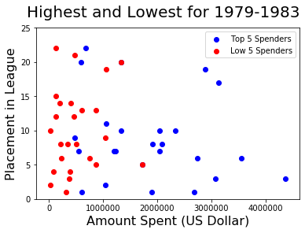

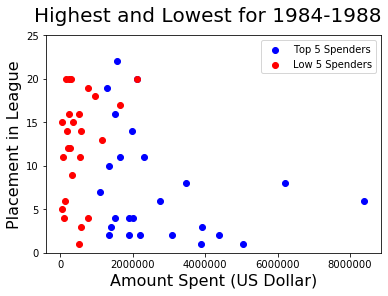

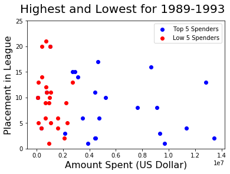

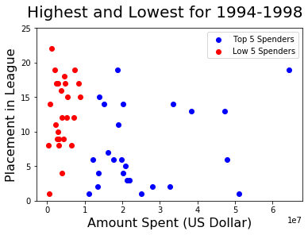

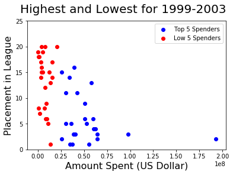

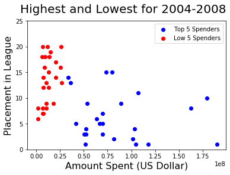

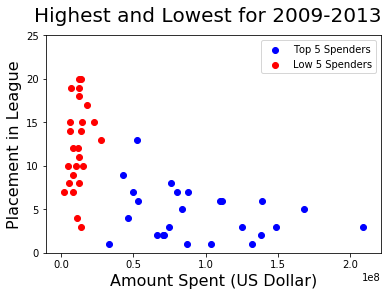

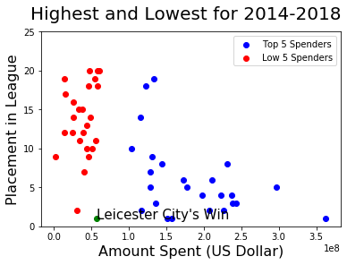

```python
# Copying combined DataFrame so as to not mess with the values
df4 = pd.DataFrame(df3)

startYear = 1979

# Going through and making 8 groupings of 5 year intervals
for i in range (0, 8):
    currentYear = startYear + (5 * i)

    # Going through and grabbing the top 5 and lowest 5 for each of the 5 years in the interval
    for j in range(0, 5):
        current = df4[df4['Season'] == currentYear + j]

        topFive = maxFive(current)
        lowFive = minFive(current)

        # Converting the string version of the position to an integer for both top and bottom five
        topFive['pos'] = 20
        lowFive['pos'] = 20

        for k, l in topFive.iterrows():
            topFive.at[k,'pos'] = int(topFive.loc[k,'Pos'])

        for k, l in lowFive.iterrows():
            lowFive.at[k,'pos'] = int(lowFive.loc[k,'Pos'])

        plt.ylim([0, 25])

        plt.scatter(topFive['spent'], topFive['pos'], c='blue')
        plt.scatter(lowFive['spent'], lowFive['pos'], c='red')

    # Finding Leicester and plotting them in their title winning season
    if (i == 7):
        season2015 = df4[df4['Season'] == 2015]
        leicester = season2015[season2015['Team'] == "Leicester City"]

        spent = actualVal(leicester['Expenditure'].values[0])

        plt.scatter(spent, leicester['Pos'], c='green')
        plt.annotate("Leicester City's Win", (spent, leicester['Pos']), fontsize=15)

    # Labeling the various parts of the graph
    plt.suptitle('Highest and Lowest for ' + str(currentYear) + '-' + str(currentYear + 4) , fontsize=20)
    plt.xlabel('Amount Spent (US Dollar)', fontsize=16)
    plt.ylabel('Placement in League', fontsize=16)
    plt.gca().legend(('Top 5 Spenders','Low 5 Spenders'))
    plt.show()
```

Based on the graphs, we can see that as years go by, spending increases as seem by the added "le7" and "le8" on the X axis that represents the amount spent in US Dollars. It is also easy to tell how spending is correlated to league table placement. The Y axis is the numerical placement in the league table. This means that the number one team in the league is at the bottom of the graph near the graph's origin point.

Teams the spend the least amount of money float towards the top left corner of the graph. On the opposite side, teams that spend the most amount of money appear towards the bottom right hand corner of the graph. This shows us that teams that spend more money tend to be at the top of the league table while those who spend less gravitate towards to bottom of the table.

It is important to note that at the beginning of this timeline, 1979, soccer a popular sport earning a fair bit of money. However, nothing compares up to today's revenues for the sport. The modern game of soccer has began to slightly deter from the game itself and start an increasing focus towards money and fanbases. Teams are constantly under investigations for cases of fraud or club (Football Club) owners funeling money from outside the jurisdiction of FIFA. This is another part of the game itself that can be noticed in the graphs - money increasingly defines the game as time goes by.

There's a lot of articles out there that go into depth about money in soccer, specifically the Premier League. Manchester City, a Premier League team that generally hangs out at the top of the league table, is currently being investigated for breaking Financial Fair Play regulations which ensures that soccer teams only recieve a certain amount of money from specific sources. You can read more about it here if interested: https://www.cnn.com/2019/05/16/football/manchester-city-uefa-financial-fair-play-champions-league-spt-intl/index.html

# Machine Learning

We now want to feed information to the machine to see what predictions we get based on the data we have.

## Creating and Training Model

To make sure we do not change the original data, we make a copy of the DataFrame once again. We then make the 'spent' column of the DataFrame copy to equal 0. We will be creating and training a model to predict how much a team spends and where it puts them in the league table rankings based on the data we provide.

Like last time, we start at year 1979 and will keep the same 8 groups of 5 year intervals.

```python
# Copying the DataFrame so as to not damage the original data
df5 = pd.DataFrame(df4)

# Convertin the Expenditure column into integers (they are formatted as a string of ${some number}m/k)
df5['spent'] = 0

for i, j in df5.iterrows():
    df5.at[i,'spent'] = actualVal(df5.loc[i,'Expenditure'])

df5 = df5[df5.spent != 0]

# Setting the start year
startYear = 1979

# For the predictions, we will keep the same groupings of every 5 years in the range

# Lumping the years into 8 different categories
for i in range (0, 8):

    # Shifting years by 5
    currentYear = startYear + (5 * i)

    # Here, we grab the 5 years
    fiveYearPeriod = df5[(df5['Season'] >= currentYear) & (df5['Season'] < (currentYear + 5))]

    # Here, we grab the amount spend and positions in the table
    x1 = fiveYearPeriod['spent']
    y1 = fiveYearPeriod['Pos']

    x1 = x1.values.reshape(-1, 1)
    y1 = y1.values.reshape(-1, 1)

    # Training our model
    X_train, X_test, y_train, y_test = model_selection.train_test_split(x1, y1, test_size=0.3)
    regression = linear_model.LinearRegression().fit(X_train, y_train)
```

## Creating Test Values

```python
# Here, we are making test values by taking the min and max spent values,
fiveYearPeriod.sort_values(by=['spent'])
maxVal = fiveYearPeriod.tail(1)["spent"].values
minVal = fiveYearPeriod.head(1)["spent"].values
difference = maxVal - minVal

divisor = 5
interval = difference / divisor

testValues = []
testValues.append(minVal)

for j in range(1, divisor - 1):
    testValues.append(minVal + (j * interval))

testValues.append(maxVal)
```

## Making Predictions and Graphing

Finally, we make the actual predicition using the test values we created with the collected data to see what is predicted for these teams.

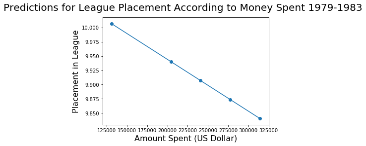

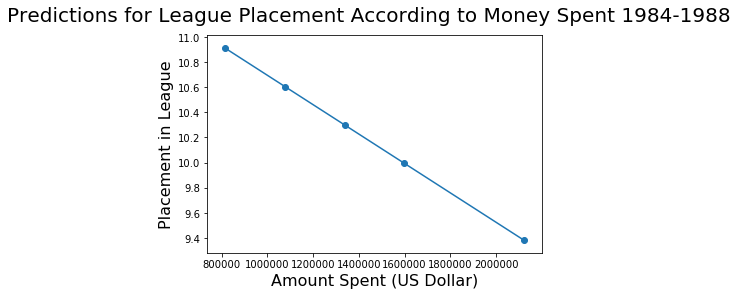

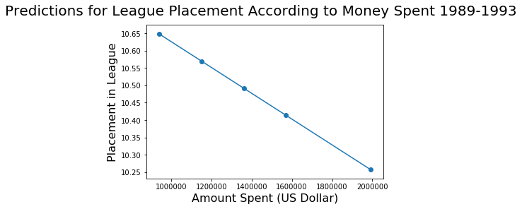

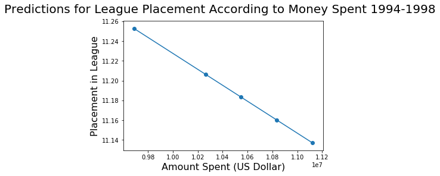

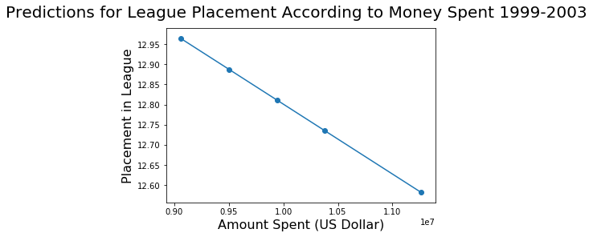

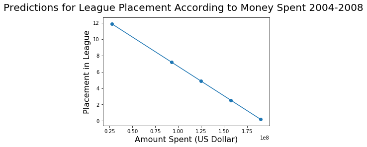

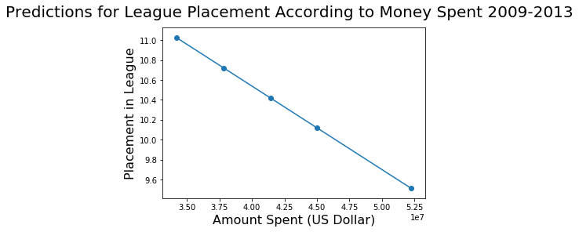

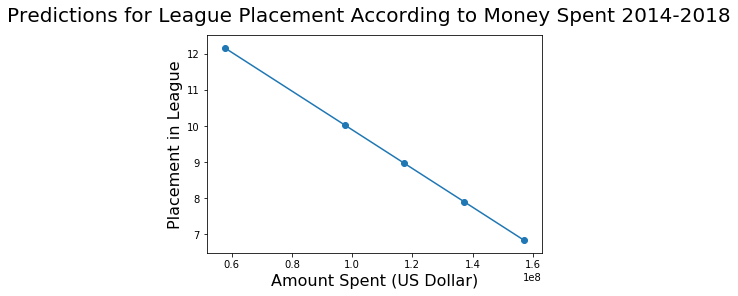

```python
# Making the actual predictions
prediction = regression.predict(testValues)

# Plotting the predictions
plt.plot(testValues, prediction)
plt.scatter(testValues, prediction)
plt.suptitle('Predictions for League Placement According to Money Spent ' + str(currentYear) + '-' + str(currentYear + 4) , fontsize=20)
plt.xlabel('Amount Spent (US Dollar)', fontsize=16)
plt.ylabel('Placement in League', fontsize=16)
plt.show()
```

## Prediction Analysis

Taking a look at our predictions, it is evident the effect that money is had over time in the league when given context. Early on all across Europe, teams were less willing to spend on international players. They would rather promote homegrown talent in their teams. Because of this, teams spent less. Spending did not have as big of an effect on the table as other factors, such as having a good youth academy. This can be seen in the first few grouping of our predictions graph, as the y-axis shows the difference between the bigger spenders and the lower spenders is smaller than 1 in most cases. In the past 10 - 15 years though, the bigger teams have been greatly outspending the smaller teams for the best international talent. This spending to gain higher positions in the table, which was seen in the plotting of the highest and lowest spenders, can be seen with the predictions graph as well. The y-axis shows that margin between bigger spenders and lower spenders grows significantly, which the difference being more than 5 spots in some of the groupings.

# Conclusion

While money might not be the only reason that a team may do well, it is increasingly showing up that spending more money than your opposition is going to win you games. Leicester City was a very rare case in modern soccer, which created a thrilling season for fans around the world. With the money they had invested, it was not predicted that they would make it in the top half of the table. This, combined with the fact that it was only their second season after being promoted to the top flight of English soccer, makes for one of the greatest stories in the game.

The league in the past few seasons has seen unbelievable amounts of spending. It creates the debate whether this spending is technically fair for all of the teams in the league, as many teams who do not earn enough often fall to the bottom of the table. Specifically, the bottom three teams in the table who end up thrown into the division below through relegation. It is still a controversial topic in the league, but the work here sheds light on the definite impact cause by money in the modern game.